# 🧬 R Programming Fundamentals

Lecture 5: Core Syntax, Data Types & Computational Logic

Fighting Cancer with Transcriptomics 2026

2026-10-07

## 🗺️ Where We Are in the Course

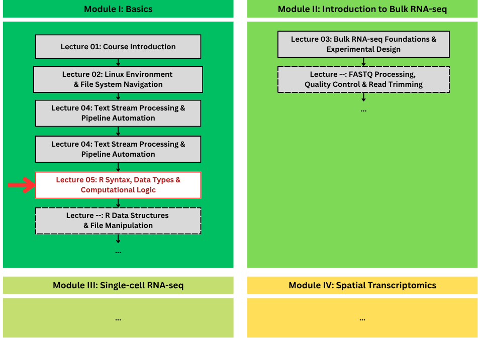

## Why R?

## 🧬 The REAL Scale of Transcriptomics

Modern cancer transcriptomics produces **massive, high-dimensional datasets**:

- **Bulk RNA-Seq:**
  - ~20,000 human genes quantified across patient cohorts.
  - Millions of sequencing reads per sample.

🧬 The REAL Scale of Transcriptomics

### Example: Bulk RNA-Seq Count Matrix

How raw transcriptomic data looks in a computational matrix

| Gene ID | Tumor_P1 | Tumor_P2 | Normal_P1 | Normal_P2 |
| --- | --- | --- | --- | --- |
| **TP53** | 12,450 | 14,210 | 8,920 | 9,150 |
| **BRCA1** | 3,420 | 4,890 | 1,230 | 1,410 |
| **EGFR** | 45,820 | 38,100 | 5,420 | 6,100 |
| **GAPDH** | 102,400 | 98,350 | 95,800 | 99,200 |
| *(… 19,996 more)* | … | … | … | … |

**Note**

Notice how `GAPDH` (housekeeping) is steady across all samples, while oncogenes like `EGFR` are specifically amplified in Tumor samples!

🧬 The REAL Scale of Transcriptomics

### Modern cancer transcriptomics

produces **massive, high-dimensional datasets**:

- **Single-Cell & Spatial Transcriptomics:**
  - Measures expression across **thousands of individual cells** or **tissue spots**.
  - Count matrices easily exceed **MILLIONS** of data points per tumor biopsy.

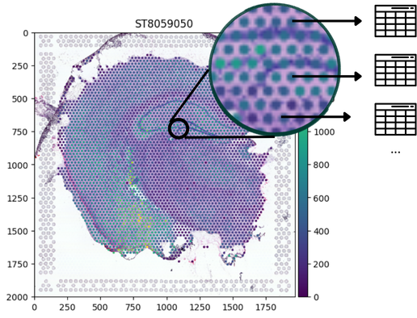

Source: [spatialdata.scverse.org](https://spatialdata.scverse.org/en/latest/tutorials/notebooks/notebooks/examples/technology_visium.html)

## ⚠️ Why Excel isn’t the tool?

⚠️ Why Excel isn’t the tool?

### 1. Gene Date Corruption

- **Silent auto-conversion:**
  - `SEPT2` $\rightarrow$ **2-Sep**
  - `MARCH1` $\rightarrow$ **1-Mar**
- **>30% of published genomics papers** contained Excel date errors in supplementary files.
- Once saved, original gene identities are **PERMANANTLY** lost.

⚠️ Why Excel isn’t the tool?

### 2. Hard Capacity Limits

- **1,048,576 rows** hard ceiling per sheet.
- Spatial & single-cell datasets profile 20,000+ genes $\times$ tens of thousands of spots/cells.
- Large matrices easily **crash** or silently **truncate** data.

⚠️ Why Excel isn’t the tool?

### 3. Lack of Reproducibility

- **No audit trail:** Point-and-click edits leave no record.
- Impossible to trace cell filtering, modifications, or outlier removal.
- **Code is a protocol:** R scripts are version-controlled, automated, and 100% reproducible.

## 💡 Instead… We use R! (and Bioconductor)

[figure not shown]

💡 Instead… We use R! (and Bioconductor)

### 1. The Bioconductor Ecosystem

- **Purpose-built for genomics:** 2,000+ specialized, peer-reviewed packages.
- **Cancer & spatial standards:** Standardized data structures for bulk, single-cell, and spatial transcriptomics.

[figure not shown]

[figure not shown]

[figure not shown]

[figure not shown]

[figure not shown]

💡 Instead… We use R! (and Bioconductor)

### 2. 100% Reproducible Research

- **Self-documenting workflows:**
  - Every normalization, filter, and cutoff is explicitly preserved in code.
- **Full audit trail:**
  - Anyone can re-run the script from raw data to reproduce the exact same results.

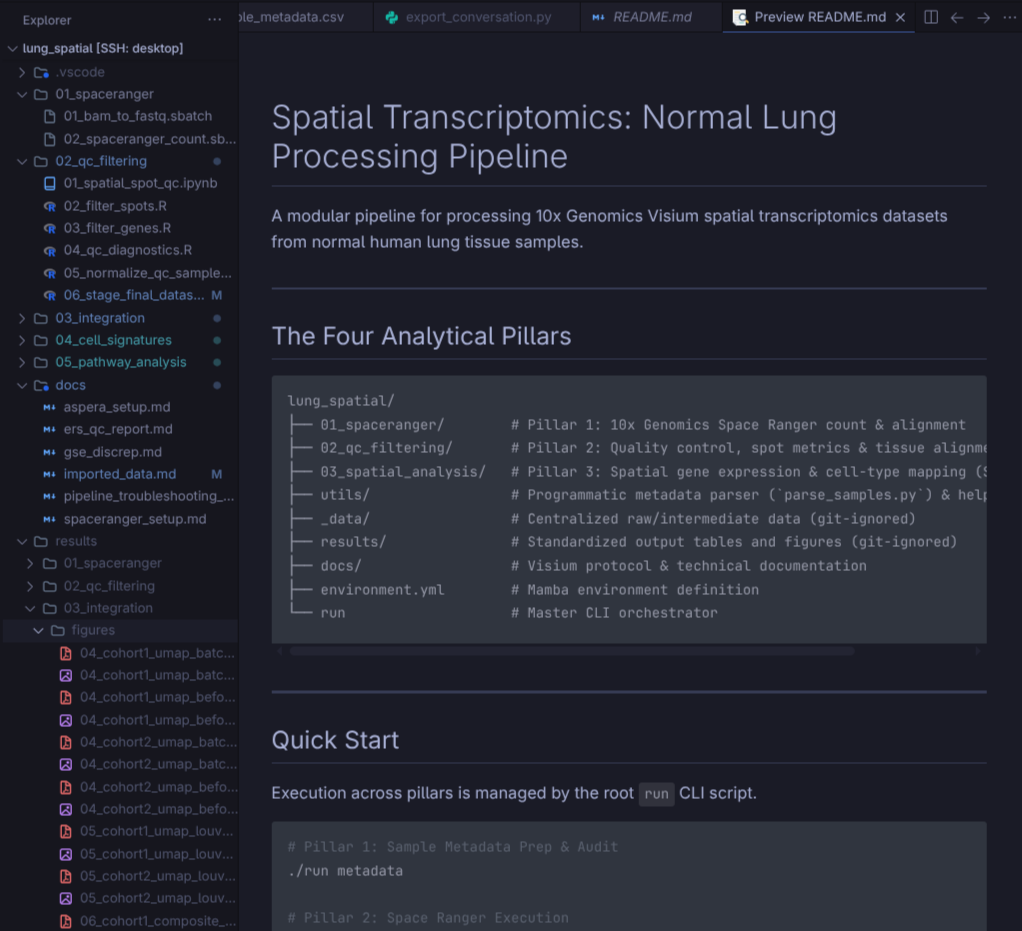

💡 Instead… We use R! (and Bioconductor)

### 3. Publication-Grade Visualizations

- **High-impact science communication:**
  - Powered by `ggplot2` and specialized spatial graphics engines.
- **Pixel-perfect control:**
  - Volcano plots, Heatmaps, and Spatial tissue overlays built directly for publication.

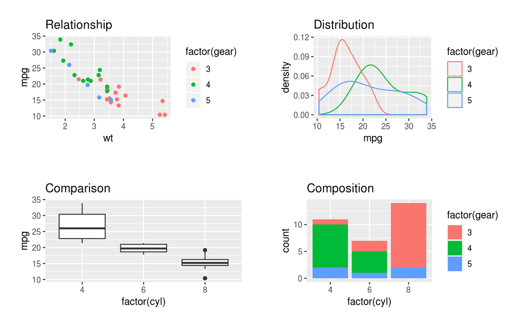

Source: [benwhalley.github.io](https://benwhalley.github.io/just-enough-r/layered-graphics.html)

## 🛠️ How to Install R?

🛠️ How to Install R?

### 4 Ways to Get R Running

- **1. Local install** — R from **CRAN** + **RStudio Desktop** on your own machine
- **2. Google Colab** — R on Google’s servers, nothing to install: colab.to/r
- **3. Micromamba** — a reproducible `environment.yml` toolbox (our course standard)
- **4. Posit Cloud** — hosted RStudio in your browser, nothing to install

**🎯 Pick one for today**

Any of the four runs the exact same R. Start with the easiest, add the others when you need them.

🛠️ How to Install R?

### The Local Route: CRAN + RStudio

R is **free and open source**: install **R** (the engine that runs your code), then **RStudio** (the editor you work in).

### Install R

- **CRAN for Linux**: cloud.r-project.org/bin/linux → pick your distro
- Debian/Ubuntu shortcut: `sudo apt install r-base r-base-dev`

### Install RStudio

- **Posit**: [posit.co/download/rstudio-desktop](https://posit.co/download/rstudio-desktop/) — `.deb` for Debian/Ubuntu, `.rpm` for Fedora
- Auto-detects your R on launch

**🧩 Engine vs. Editor**

R is the language; RStudio is the cockpit. Keep `Rscript` for cluster pipelines.

🛠️ How to Install R?

### RStudio IDE

[figure not shown]

**🧭 Never lose your work**

An unsaved script is lost forever — use `File → Save` (`Ctrl/Cmd + S`) after every edit.

🛠️ How to Install R?

### VS Code Works Too!

#### Install & Extend

- Download → code.visualstudio.com
- Extensions (`Ctrl/Cmd + Shift + X`):
  - **R** (by *Posit*) → REPL, highlighting, debugger, plot pane.

#### Point It at Your R

- `R: Select R interpreter` → choose your R
- Type in the **R Terminal**, `Ctrl + Enter` runs the line — just like RStudio’s console.
- Shell: `code analysis.R` · headless: `Rscript analysis.R`

**🤝 Either Editor Is Fine**

RStudio is all-in-one; VS Code wins when you work across languages. Both run the exact same R.

🛠️ How to Install R?

### R in Google Colab - Skip Installation Entirely!

[Google Colab](https://colab.research.google.com) runs **R on Google’s servers in your browser** — nothing to install, and the notebook lives in your Drive.

- Open an R notebook at **colab.to/r**, or set `Runtime → Change runtime type → R`
- Type code in a **code cell**, then press **`Ctrl + Enter`** (`Cmd + Enter` on Mac)
- Missing a package? Install it once, then load it:

```r
# 1. Install (once per session)
install.packages("ggplot2")

# 2. Load it so your code can use it
library(ggplot2)
```

**⚠️ Colab Is Not Persistent**

Colab runs on a temporary server — when the session disconnects or goes idle it is wiped clean, and every installed package and uploaded file disappears. Save anything you want to keep to your Drive before you close the tab.

## 📋 1. Syntax, Comments & Output

- **1. Syntax, Comments & Output**
- 2. Variables & The Assignment Operator (`<-`)
- 3. Core Data Types & Values
- 4. R Math Functions & Arithmetic Operators
- 5. Strings & Escape Characters
- 6. R Operators
- 7. Control Flow (If…Else, Loops)
- 8. Practice Exercises
1. Syntax, Comments & Output

### Hello World! 🌏

In R, code executes sequentially from top to bottom.

**Note**

1. Syntax, Comments & Output

### Let’s do some math! 🔢

In R, bare expressions evaluate and print their result automatically.

**Tip**

You do not need to wrap math inside `print()`.

1. Syntax, Comments & Output

### Displaying Values with `print()` 🖨️

Use `print()` to display text messages and numeric values to the console:

**Note**

Notice that `print()` outputs `[1]` before the value. This indicates that the output is a vector whose first element starts at index 1!

1. Syntax, Comments & Output

### Uh oh! ⁉️ Mistakes Happen… A LOT!

- If you miss a closing quote (`"`) or parenthesis (`)`), R **does not crash**.
- It waits on a new line showing a **`+` prompt**!

**💡 How to Rescue Your Console**

Press **`Escape`** or **`Ctrl + C`** to cancel and recover your prompt `>`!

**Golden Rule:** Quotes `""` and parentheses `()` must always match in pairs.

1. Syntax, Comments & Output

### ✍️ Exercise 1.1: Spot Count Check

Your Turn!

1. Write a comment with your name and today’s date.
2. Print the message: `"Preprocessing..."`
3. Calculate the total spots on a slide by adding `4992 + 1200` using `print()`.
1. Syntax, Comments & Output

### ✅ Exercise 1.1: Spot Count Check

Solution:

In 10x Visium, each standard capture area contains exactly **4,992** barcoded spots!

## 📋 2. Variables & The Assignment Operator (`<-`)

- 1. Syntax, Comments & Output
- **2. Variables & The Assignment Operator (`<-`)**
- 3. Core Data Types & Values
- 4. R Math Functions & Arithmetic Operators
- 5. Strings & Escape Characters
- 6. R Operators
- 7. Control Flow (If…Else, Loops)
- 8. Practice Exercises
2. Variables & The Assignment Operator (<-)

### Named Storage Containers in Memory

A **variable** is a named storage container in your computer’s memory.

**💡 Why not `=`?**

While `=` works, R and Bioconductor standards strictly recommend **`<-`** for variable assignment, reserving `=` for passing arguments inside functions!

2. Variables & The Assignment Operator (<-)

### Rules for Variable Names

### ✅ DOs

- **Must start with a letter:**
- **Can contain:**
  - Letters, numbers, underscores (`_`), and periods (`.`)
- **Clean, descriptive names** make code readable for peers and reviewers!

### 🛑 DON’Ts

- **Cannot start with a number:**
  - `1gene` causes a syntax error!
- **Cannot contain spaces:**
  - `cell count` is invalid!
- **R is strictly case-sensitive:**
  - `Gene_A`, `gene_A`, and `gene_a` are **3 completely different variables** in memory!
2. Variables & The Assignment Operator (<-)

2. Variables & The Assignment Operator (<-)

### ✅ Solution: Hyphens in names

**💡 Why underscores work**

R variable names cannot contain math operators like `-`. Use `snake_case` instead.

2. Variables & The Assignment Operator (<-)

### 🔍 Spot the Error!

2. Variables & The Assignment Operator (<-)

### ✅ Solution: Leading digits

**💡 Why names must start with a letter**

R requires variable names to begin with an alphabetic letter.

2. Variables & The Assignment Operator (<-)

### 🔍 Spot the Error!

2. Variables & The Assignment Operator (<-)

### ✅ Solution: Variables are Case-sensitive

**💡 Why casing matters**

`target_gene` and `Target_gene` refer to two completely different memory locations!

2. Variables & The Assignment Operator (<-)

### Use `snake_case` for Readability

In standard bioinformatics and tidy R workflows, use **`snake_case`** (all lowercase words separated by underscores):

**Tip**

Using lowercase with underscores avoids accidental typos, prevents case-sensitivity errors, and keeps pipelines clean!

2. Variables & The Assignment Operator (<-)

### ✍️ Exercise 1.2: Calculating Background Spots

Your Turn!

1. A 10x Visium slide has `4992` total capture spots. Assign this number to a variable named `total_spots`.
2. Microscope imaging reveals that `3820` spots are covered by tissue. Assign this to `tissue_spots`.
3. Calculate the number of background (empty) spots and store it in `background_spots`.
4. Print the result using `print(background_spots)`.
2. Variables & The Assignment Operator (<-)

### ✅ Exercise 1.2: Calculating Background Spots

Solution:

**Tip**

In spatial analysis, tissue spots capture cellular mRNA, while background spots are filtered out during quality control!

## 📋 3. Core Data Types & Values

- 1. Syntax, Comments & Output
- 2. Variables & The Assignment Operator (`<-`)
- **3. Core Data Types & Values**
- 4. R Math Functions & Arithmetic Operators
- 5. Strings & Escape Characters
- 6. R Operators
- 7. Control Flow (If…Else, Loops)
- 8. Practice Exercises
3. Core Data Types & Values

Every piece of data in R belongs to a specific atomic type:

| Type | What It Stores | Real Genomics Example |
| --- | --- | --- |
| **`numeric`** | Decimals / Floats (default in R) | `log2_fc <- 2.45` |
| **`integer`** | Discrete counts / whole numbers (`L`) | `raw_reads <- 12450L` |
| **`character`** | Text strings (`""`) | `gene_name <- "TP53"` |
| **`logical`** | Boolean (`TRUE`/`FALSE`, no quotes!) | `is_de_gene <- TRUE` |

**Note**

In R, numbers default to `numeric` (double). To explicitly store an integer (e.g., spot index or raw read count), append an `L` like `4992L`.

3. Core Data Types & Values

Inspect any variable with `typeof()` or `class()`:

3. Core Data Types & Values

### 🧬 Bioinformatics Pitfall: Type Coercion

Vectors can hold only **one** type! If you mix types, R silently coerces everything to the most flexible type (**character**):

3. Core Data Types & Values

### ⚠️ Special Values: `NA` (Not Available)

- **`NA`** represents missing data, unmeasured spots, or biological dropouts.
- Extremely common in single-cell & spatial transcriptomics datasets.
- Test for missing values using **`is.na()`** (never `== NA`):

**💡 Gotcha: Never use `== NA`**

`x == NA` returns `NA` because comparing anything to an unknown is unknown. Always use `is.na(x)`!

3. Core Data Types & Values

### ⚠️ Special Values: `NaN` (Not a Number)

- **`NaN`** stands for **“Not a Number”**.
- Occurs when a mathematical operation is undefined or impossible (e.g., $0 / 0$).
- Test for undefined values using **`is.nan()`**:

**Tip**

In single-cell normalization, dividing a gene count of 0 by an empty spot’s library size of 0 yields `NaN`.

3. Core Data Types & Values

### ⚠️ Special Values: `Inf` & `-Inf` (Infinity)

- **`Inf`** and **`-Inf`** represent values exceeding numerical bounds.
- Arises when dividing non-zero numbers by zero, or taking the logarithm of zero ($\log(0)$).

**🧬 Transcriptomic Connection**

Gene count matrices contain many zeros. Taking $\log_2(0) = -\infty$ crashes statistical pipelines — which is why we add a **pseudo-count** ($\log_2(\text{count} + 1)$)!

## 📋 4. R Math Functions & Arithmetic Operators

- 1. Syntax, Comments & Output
- 2. Variables & The Assignment Operator (`<-`)
- 3. Core Data Types & Values
- **4. R Math Functions & Arithmetic Operators**
- 5. Strings & Escape Characters
- 6. R Operators
- 7. Control Flow (If…Else, Loops)
- 8. Practice Exercises
4. R Math Functions & Arithmetic Operators

### Standard Math Operators in Genomics

| Operator | Action | Real Genomics Example |
| --- | --- | --- |
| `+` | Addition | `tot_reads <- 12000 + 3500` |
| `-` | Subtraction | `bg_spots <- 4992 - 3820` |
| `*` | Multiplication | `mito_pct <- 0.074 * 100` |
| `/` | Division | `depth_scale <- 45 / 15000` |
| `^` | Exponentiation | `fc <- 2^3` (8-fold change) |
| `%%` | Modulo (remainder) | `batch_rem <- 10 %% 3` (1) |
| `%/%` | Floor division | `cohort_grp <- 10 %/% 3` (3) |

**Note**

In R, `%%` returns the remainder (e.g. testing for even/odd samples), while `%/%` performs floor division, discarding the fractional part.

4. R Math Functions & Arithmetic Operators
1. Square root:
2. Rounding numbers:
4. R Math Functions & Arithmetic Operators
3. Logarithms (base 2 for fold change):

**Tip**

In transcriptomics, $\log_2$ is standard because a 1-unit increase represents a **doubling (2-fold increase)** in gene expression!

4. R Math Functions & Arithmetic Operators

### The Problem: Sequencing Depth Differences

```r
# Spot A (high sequencing depth):
spot_a_total_reads <- 50 * 10^6
spot_a_gene_reads  <- 450

# Spot B (lower sequencing depth):
spot_b_total_reads <- 10 * 10^6
spot_b_gene_reads  <- 200
```

- Spot A has 50M total reads
- Spot B has only 10M total reads.

Which gene is actually expressed at a **higher relative rate**?

4. R Math Functions & Arithmetic Operators

### The Solution: Counts Per Million (CPM)

$$\text{CPM} = \left( \frac{\text{Gene Read Count}}{\text{Total Library Size}} \right) \times 10^6$$

**The Normalization Takeaway**

Raw counts deceive!

Although Spot A has more reads (450 vs 200), Spot B actually expresses the gene at **2.2× higher rate** once normalized for sequencing depth.

## 📋 5. Strings & Escape Characters

- 1. Syntax, Comments & Output
- 2. Variables & The Assignment Operator (`<-`)
- 3. Core Data Types & Values
- 4. R Math Functions & Arithmetic Operators
- **5. Strings & Escape Characters**
- 6. R Operators
- 7. Control Flow (If…Else, Loops)
- 8. Practice Exercises
5. Strings & Escape Characters

### Single vs. Double Quotes

A **string** stores text data. In R, strings can be created using matching double (`"`) or single (`'`) quotes:

- **Both Are Valid:**
  - R treats `'text'` and `"text"` identically in memory.
- **Bioinformatics Standard:**
  - Double quotes `"` are strongly preferred across Bioconductor and Tidyverse codebases.

**Golden Rule**

Never mix opening and closing types (e.g., `"text'` will throw a syntax error)!

5. Strings & Escape Characters

### Quotes Inside Quotes

What happens when your text itself contains quotation marks or apostrophes?

- **Enclose with the Opposite Type:**
  - Put **double quotes** inside **single quotes**: `'Expression: "High"'`
  - Put **single quotes (apostrophes)** inside **double quotes**: `"Patient's sample"`

**Why this matters?**

If you don’t use the opposite quote type, R gets confused about where the string ends!

5. Strings & Escape Characters

### Concatenations! 😺

To print clean sentences and combine text smoothly with variables, R provides **`cat()`** (short for con-**cat**-enate):

- **Why use `cat()`?**
  - `print()` wraps text in quotes and adds vector indices (`[1]`).
  - `cat()` combines multiple pieces into readable terminal sentences!
- **The Trailing `"\n"` Rule:**
  - Unlike `print()`, `cat()` does not add a newline automatically. Always end with `"\n"` to advance to the next line.

**Note**

Notice that `"\n"` at the end? That is an **escape character**! Let’s explore what backslashes do next!

5. Strings & Escape Characters

### Escape Characters (`\n`, `\t`, `\"`)

The backslash **`\`** is a special signal in R that modifies the character following it:

| Escape Code | Meaning | What It Does |
| --- | --- | --- |
| `\n` | New Line | Jumps down to a fresh line |
| `\t` | Tab Space | Inserts a clean column indent |
| `\"` | Double Quote | Puts literal `"` inside `"..."` |

**`\` is Special in R!**

The backslash tells R: *“Don’t treat the next character literally; it is an escape command!”*

**Tip**

Because `cat()` interprets escape sequences, `\"` renders as real quotes on screen!

5. Strings & Escape Characters

### 🔍 The Windows Path Trap — Solution

**🌐 The Universal Rule**

**ALWAYS use forward slashes `/`** in R paths across Windows, macOS, and Linux!

## 📋 6. R Operators

- 1. Syntax, Comments & Output
- 2. Variables & The Assignment Operator (`<-`)
- 3. Core Data Types & Values
- 4. R Math Functions & Arithmetic Operators
- 5. Strings & Escape Characters
- **6. R Operators**
- 7. Control Flow (If…Else, Loops)
- 8. Practice Exercises
6. R Operators

### Comparison Operators

Comparison operators test relationships between values. The result is always a **`logical`** (`TRUE` or `FALSE`).

| Operator | Meaning | Example |
| --- | --- | --- |
| `==` | Exactly equal to | `x == 10` |
| `!=` | Not equal to | `x != 10` |
| `>` | Greater than | `x > 5` |
| `<` | Less than | `x < 5` |
| `>=` | Greater than or equal to | `x >= 10` |
| `<=` | Less than or equal to | `x <= 10` |

6. R Operators

### Logical AND (`&`)

Returns `TRUE` **only if both** conditions are `TRUE`.

- Evaluates left and right conditions.
- If either side is `FALSE`, the entire result is `FALSE`.

| Left | Right | `Left & Right` |
| --- | --- | --- |
| `TRUE` | `TRUE` | **`TRUE`** |
| `TRUE` | `FALSE` | `FALSE` |
| `FALSE` | `TRUE` | `FALSE` |
| `FALSE` | `FALSE` | `FALSE` |

**Precedence Tip**

Use parentheses `(...)` around each comparison to keep compound logic clear.

6. R Operators

### Logical OR (`|`)

Returns `TRUE` if **at least one** condition is `TRUE`.

- Evaluates left and right conditions.
- Returns `FALSE` **only if both** sides are `FALSE`.

| Left | Right | `Left \| Right` |
| --- | --- | --- |
| `TRUE` | `TRUE` | `TRUE` |
| `TRUE` | `FALSE` | `TRUE` |
| `FALSE` | `TRUE` | `TRUE` |
| `FALSE` | `FALSE` | **`FALSE`** |

6. R Operators

### Logical NOT (`!`)

Inverts any truth value (`TRUE` $\rightarrow$ `FALSE`, `FALSE` $\rightarrow$ `TRUE`).

- Reverses a logical condition.
- Useful to negate flags or keep unflagged samples.

| Input | `!Input` |
| --- | --- |
| `TRUE` | **`FALSE`** |
| `FALSE` | **`TRUE`** |

6. R Operators

### 🔍 Practice: Spot Quality Filter

Write a compound logical expression for `keep_spot`. It should evaluate to `TRUE` **only if all 3** conditions pass:

1. `on_tissue` is `TRUE`
2. `gene_count` is at least `500` AND at most `2500`
3. `mito_pct` is less than `20.0`
6. R Operators

### ✅ Solution — Spot Quality Filter

Overall: `TRUE & TRUE & FALSE` $\rightarrow$ **`FALSE`** (spot is filtered out).

**Chaining Range Checks**

In R, you cannot write `500 <= gene_count <= 2500`. You must write two separate comparisons joined by `&`: `(gene_count >= 500) & (gene_count <= 2500)`.

## 📋 7. Control Flow (If…Else, Loops)

- 1. Syntax, Comments & Output
- 2. Variables & The Assignment Operator (`<-`)
- 3. Core Data Types & Values
- 4. R Math Functions & Arithmetic Operators
- 5. Strings & Escape Characters
- 6. R Operators
- **7. Control Flow (If…Else, Loops)**
- 8. Practice Exercises
7. Control Flow (If…Else, Loops)

### Conditional Branching (`if...else`)

- **`if`**: Runs code block only if condition is `TRUE`.
- **`else`**: Catch-all fallback if condition is `FALSE`.

**R Syntax Requirement**

`else` must always be on the **same line** as the closing brace `}`: `} else {`

7. Control Flow (If…Else, Loops)

**What if you need more conditions?**

- Use `else if` to test additional checks in order.
- R runs the **first** branch that is `TRUE`, then stops.
- `else` catches whatever is left over.
7. Control Flow (If…Else, Loops)

### `for` Loops (Iterating Vectors)

A `for` loop executes a block of code once for each element in a vector:

- Iterates sequentially through items in a collection.
- Inside the loop, the variable (e.g., `gene`) holds the current value.
- Commonly used to batch-process gene lists, spots, or file paths.
7. Control Flow (If…Else, Loops)

### Skip with `next`

- **`next`** skips the rest of the current iteration.
- The loop immediately jumps to the next item in the vector.
- Useful for filtering out low-quality spots without stopping the entire run.
7. Control Flow (If…Else, Loops)

### Take a `break`!

- **`break`** terminates and exits the loop immediately.
- No remaining items are processed.
- Useful for error aborts, corrupted inputs, or stopping early once a condition is met.
7. Control Flow (If…Else, Loops)

### `while` TRUE?

Repeats code block as long as a condition stays `TRUE`:

- Condition is checked **before** each iteration.

**Avoid Infinite Loops**

- If the condition never turns `FALSE`, the loop runs infinitely!
- Always increment or adjust your counter variable inside the loop body.
7. Control Flow (If…Else, Loops)

### 🔍 Practice: Filter & Tier Spots

Write a `for` loop that iterates over `spot_counts`:

1. If count is below `50`, **skip it** using `next`.
2. Otherwise, check if count is `>= 1000`:
   - If `>= 1000`, print: `"Count [x]: High"`
   - If `< 1000`, print: `"Count [x]: Standard"`
7. Control Flow (If…Else, Loops)

### ✅ Solution — Filter and Tier Spots

**Early Exits with `next`**

Using `next` at the top of a loop is known as a **guard clause**. It keeps subsequent logic cleaner by discarding invalid inputs early.

## 📋 8. Practice Exercises

- 1. Syntax, Comments & Output
- 2. Variables & The Assignment Operator (`<-`)
- 3. Core Data Types & Values
- 4. R Math Functions & Arithmetic Operators
- 5. Strings & Escape Characters
- 6. R Operators
- 7. Control Flow (If…Else, Loops)
- **8. Practice Exercises**
8. Practice Exercises

### 🧑‍💻 Hands-on!

**📓 Interactive Notebook**

Launch the companion notebook: lecture-05_r_fundamentals_practice.ipynb

## 🚀 What’s Next?

### R Data Manipulation - From single values to biological datasets.

In the next session, we will learn how to load 10x Genomics Visium count matrices and spot coordinates into R!

- **Loading External Files**: Read spatial matrices with `read.csv()` and fast `fread()`.
- **Vectors & Factors**: Handle thousands of gene readouts at once.
- **Matrices & Data Frames**: Work with spatial spot tables and metadata.

## Thank You!

> *“Coding in R is built through muscle memory. Type the code yourself, inspect your variables, and don’t fear errors—they are your best teachers!”*